# Part II - **Presentation des résultats de l'exploration de l'ensemble de données "prosperLoanData"**

## Par Abdel Karim MOUAMFON

## Aperçu de l'enquête

> Notre enquête qui à porté sur l'exploration de l'ensemble des données **prosperLoanData** nous a permi d'observer la distribution du statut d'un prêt. Par cela, nous avons également pu dégager les correlations entre le statut du prêt et les autres caractéristiques telles que la mensualité prévu de paiement, le montant initial du prêt, le statut de l'emploi de l'emprunteur, la durée du prêt ainsi que la profession de l'emprunteur.

## Aperçu de l'ensemble de données

> L'ensemble de données **prosperLoanData** dont nous sommes sur le point d'explorer contient 113 937 prêts avec 81 variables sur chaque prêt, y compris le montant du prêt, le taux de l'emprunteur (ou taux d'intérêt), le statut actuel du prêt, le revenu de l'emprunteur, et bien d'autres.

## **Distribution des statuts des prêt**

> Nous présentons ici la distribution des statuts des prêt qui, comme on peut le voir, est largement dominé pas les prêts *En cours*. L'interêt pour cette présentation pour nous est ressortir les différentes proportions de l'état des prêts.

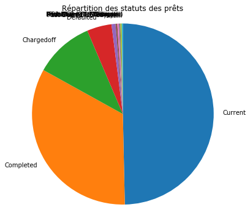

## **Répartition des statuts d'emploi des emprunteurs**

> La répartition des types d'emploi est largement dominée par les emprunteurs *Employé*

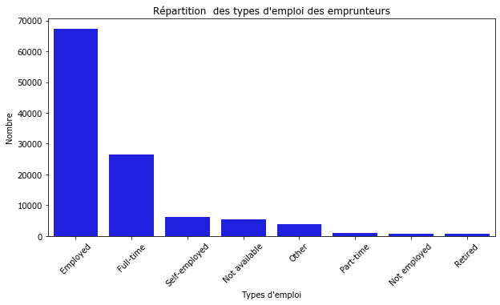

## **Correlation entre le montant initial et la mensualité prévue du prêt**

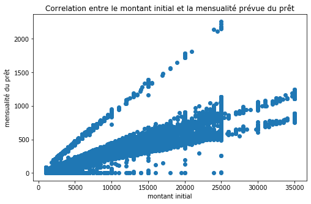

## **Correlation entre mensualité prévue et statut du prêt**

> Mensualité prévue du prêt élevée est dominée par les prêts *En cours*; par contre, les prêts à faible mensualité ont été annulé.

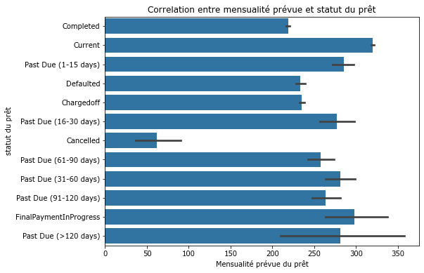

## **Relation entre le statut de l'emploi, mensualité de paiement et état du prêt**

> Les prêts annulés ont une mensualité prévue de moins de 100$ et les emplois impactés sont ceux non disponible et à temp plein.

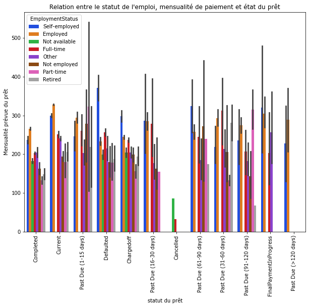